# DATA 624: Homework 5

Andrew Bowen

2024-02-25

## Exercise 8.1

First, let’s construct our time series for pigs slaughtere din Victoria and plot

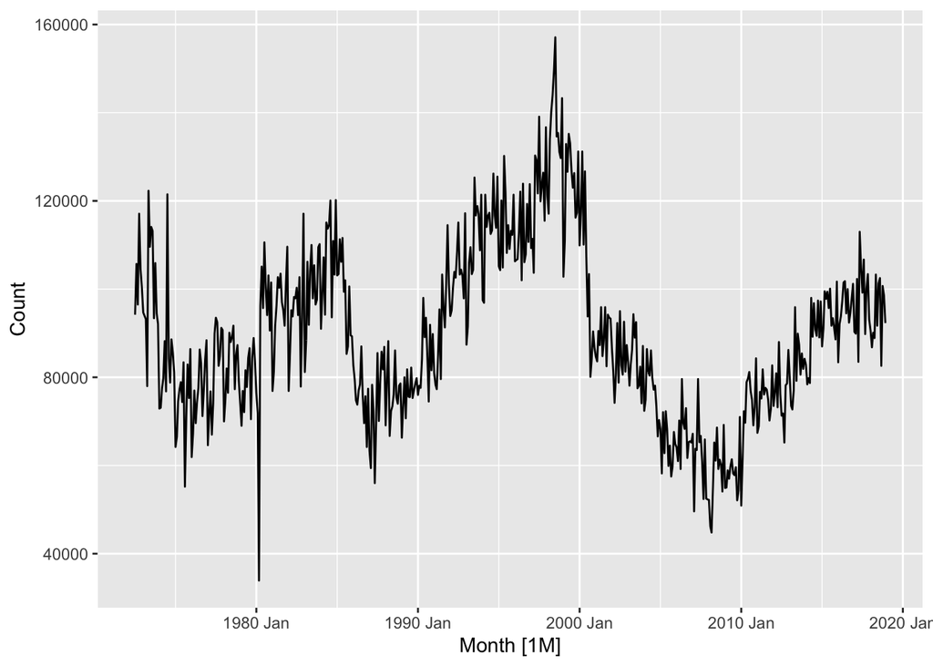

```r
victoria_pigs <- aus_livestock %>% filter(Animal == "Pigs" & State == "Victoria")

victoria_pigs %>% autoplot(Count)
```

There doesn’t appread to be strong seasonality or a general overall trend in this time series, so simple exponential smoothing makes sense to use. Now, let’s construct a model via the ETS function for SES. We’ll mirror the techniques used in Hyndman

```r
# Fit model with only an error term to reflect SES
fit <- victoria_pigs %>%
  model(ETS(Count ~ error("A") + trend("N") + season("N")))
fc <- fit |>
  forecast(h = 4)
```

Plotting our forecast over our time series gives us the following

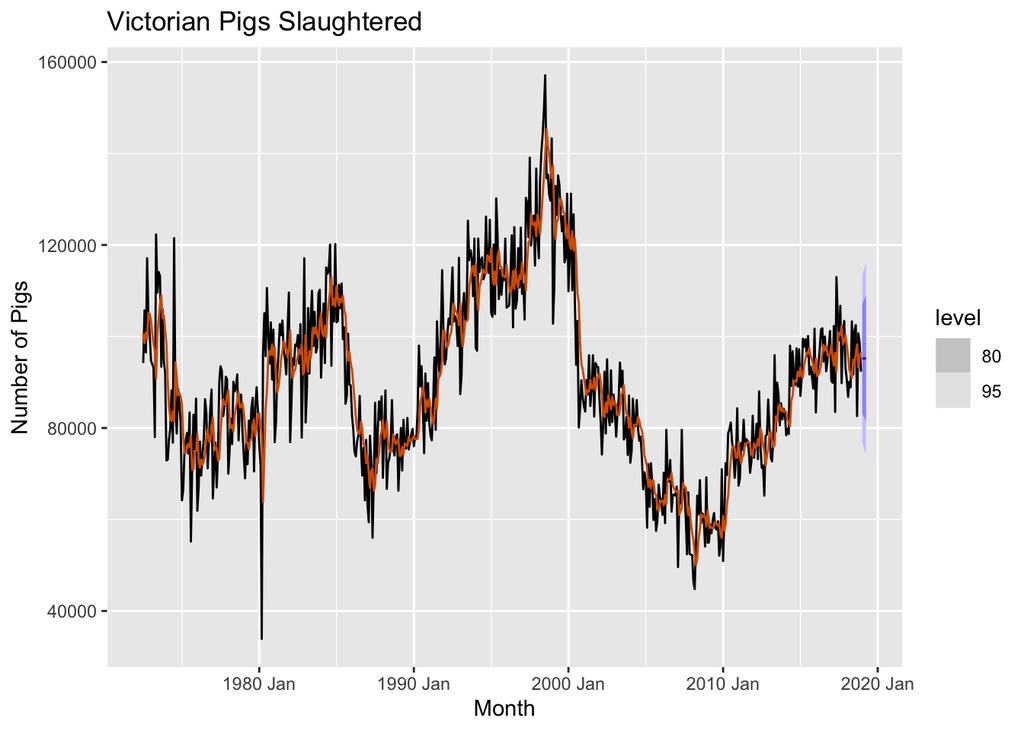

```r
# Plot victorian pigs model
fc |>
  autoplot(victoria_pigs) +
  geom_line(aes(y = .fitted), col="#D55E00",
            data = augment(fit)) +
  labs(y="Number of Pigs", title="Victorian Pigs Slaughtered") +
  guides(colour = "none")
```

To find the optimized values fo $\alpha$ and $l_0$, we can use the `report` function on our `fit` mable. We see optimized values for each parameter in our SES model below:

```r
fit %>% report()
```

```
## Series: Count
## Model: ETS(A,N,N)
##   Smoothing parameters:
##     alpha = 0.3221247
##
##   Initial states:
##      l[0]
##  100646.6
##
##   sigma^2:  87480760
##
##      AIC     AICc      BIC
## 13737.10 13737.14 13750.07
```

## Exercise 8.5

We can look at the export data from France

```r
# Add fill_gaps for later pltting/forecasting
france <- global_economy %>% filter(Country == "France") %>% fill_gaps()
head(france)
```

```
## # A tsibble: 6 x 9 [1Y]
## # Key:       Country [1]
##   Country Code   Year           GDP Growth   CPI Imports Exports Population
##   <fct>   <fct> <dbl>         <dbl>  <dbl> <dbl>   <dbl>   <dbl>      <dbl>
## 1 France  FRA    1960  62651474947.  NA     10.4    12.6    14.4   46814237
## 2 France  FRA    1961  68346741504.   5.51  10.7    12.3    13.9   47444751
## 3 France  FRA    1962  76313782252.   6.67  11.3    12.1    12.8   48119649
## 4 France  FRA    1963  85551113767.   5.35  11.8    12.5    12.6   48803680
## 5 France  FRA    1964  94906593388.   6.52  12.2    13.0    12.6   49449403
## 6 France  FRA    1965 102160571409.   4.78  12.5    12.6    13.2   50023774
```

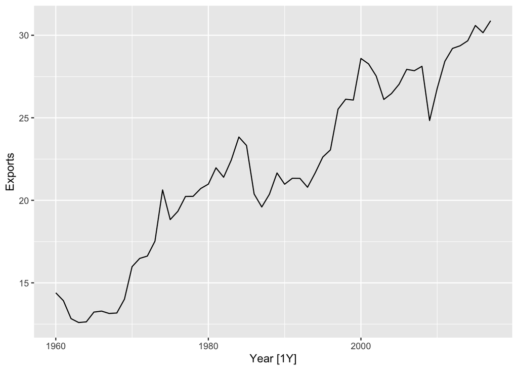

```r
france %>% autoplot(Exports)
```

While this data isn’t strongly seasonal (no noticeable patterns), there is a general upward trend in this data that may need to be accounted for.

Let’s fit an $(A, N, N)$ ETS model to this dataset and forecast out 5 years

```r
france_fit <- france %>%
  model(ETS(Exports ~ error("A") + trend("N") + season("N")))
france_fc <- france_fit %>%
  forecast(h = 5)
```

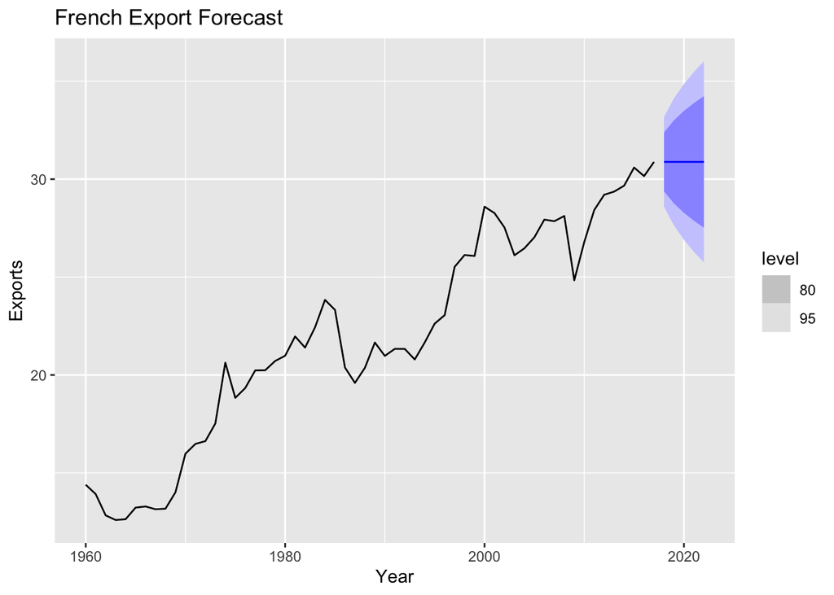

```r
france_fc %>% autoplot(france) +
  # geom_line(aes(y = .fitted), color="#456fd4" ,
  #           data = augment(france_fit)) +
  labs(y="Exports", title="French Export Forecast") +
  guides(colour = "none")
```

Now we’cc ompute RMSE values for the training data ismilar to the [method used in Hyndman](https://otexts.com/fpp3/holt.html#example-internet-usage)

```r
# Get accuracy, including RMSE
acc_ANN <- france_fit %>% accuracy()
acc_ANN
```

```
## # A tibble: 1 × 11
##   Country .model        .type    ME  RMSE   MAE   MPE  MAPE  MASE RMSSE     ACF1
##   <fct>   <chr>         <chr> <dbl> <dbl> <dbl> <dbl> <dbl> <dbl> <dbl>    <dbl>
## 1 France  "ETS(Exports… Trai… 0.284  1.15 0.840  1.17  3.86 0.983 0.991 -0.00542
```

We see an RMSE of 1.152 on our trainging data (the `france` time series). We can compare this accuracy to an $(A, A, N)$ model on the same

```r
france_fit_AAN <- france %>%
  model(ETS(Exports ~ error("A") + trend("A") + season("N")))
france_fc_AAN <- france_fit_AAN %>%
  forecast(h = 5)

# Display both accuracies
acc_AAN <- france_fit_AAN %>% accuracy()
rbind(acc_ANN, acc_AAN)
```

```
## # A tibble: 2 × 11
##   Country .model     .type      ME  RMSE   MAE    MPE  MAPE  MASE RMSSE     ACF1
##   <fct>   <chr>      <chr>   <dbl> <dbl> <dbl>  <dbl> <dbl> <dbl> <dbl>    <dbl>
## 1 France  "ETS(Expo… Trai…  0.284   1.15 0.840  1.17   3.86 0.983 0.991 -0.00542
## 2 France  "ETS(Expo… Trai… -0.0111  1.12 0.800 -0.243  3.81 0.936 0.964  0.0264
```

With an $(A, A, N)$ ETS model we see an improvement in our RMSE value. In this case a model with an (additive) trend term makes sense as the export series itself does have a general upward trend. In addition, the trend forecast (below with prediction intervals) does continue a general increase, which could be a resonable assumption for export data (generally, GDP/Export numbers will increase YoY). However, the non-trended forecaste does incorporate events that would break the upward trend (recession, etc.) better, and may be more realistic. In this case, a damped trended forecast could be a good “middle ground”

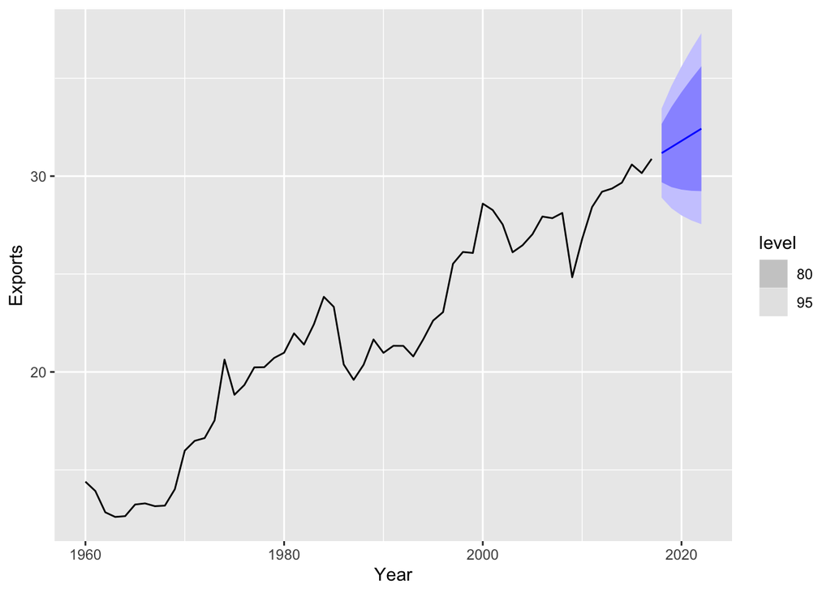

```r
france_fc_AAN %>% autoplot(france)
```

##### Prediction Intervals

Our general formula for a prediction interval is:

$$\begin{aligned}
\hat{y}_{T+h|T} = c\sigma_h
\end{aligned}$$

Where $c=1.96$ as our Z-score value for a 95% confidence interval, and $\signa_h$ is our forecast variance (given by the [Hyndman text here](https://otexts.com/fpp3/ets-forecasting.html#prediction-intervals-3))

```r
c = 1.96
# Get residuals of ANN fit
france_ANN_aug <- france_fit %>% augment()
var_ann <- var(france_ANN_aug$.resid)

france_ANN_aug$interval_lower <- france_ANN_aug$.fitted - c * var_ann
france_ANN_aug$interval_upper <- france_ANN_aug$.fitted + c * var_ann

# Get residuals of AAN fit
france_AAN_aug <- france_fit_AAN %>% augment()
var_aan <- var(france_AAN_aug$.resid)

# Calculate values
france_AAN_aug$interval_lower <- france_AAN_aug$.fitted - c * var_aan
france_AAN_aug$interval_upper <- france_AAN_aug$.fitted + c * var_aan
head(france_AAN_aug)
```

```
## # A tsibble: 6 x 9 [1Y]
## # Key:       Country, .model [1]
##   Country .model               Year Exports .fitted .resid .innov interval_lower
##   <fct>   <chr>               <dbl>   <dbl>   <dbl>  <dbl>  <dbl>          <dbl>
## 1 France  "ETS(Exports ~ err…  1960    14.4    13.7  0.711  0.711           11.2
## 2 France  "ETS(Exports ~ err…  1961    13.9    14.7 -0.752 -0.752           12.2
## 3 France  "ETS(Exports ~ err…  1962    12.8    14.3 -1.44  -1.44            11.8
## 4 France  "ETS(Exports ~ err…  1963    12.6    13.2 -0.625 -0.625           10.7
## 5 France  "ETS(Exports ~ err…  1964    12.6    12.9 -0.304 -0.304           10.4
## 6 France  "ETS(Exports ~ err…  1965    13.2    13.0  0.265  0.265           10.5
## # ℹ 1 more variable: interval_upper <dbl>
```

Alternatively, e can use the `hilo` method as well to construct a 95% confidence interval

```r
france_fc_AAN %>% hilo(level = c(95))
```

```
## # A tsibble: 5 x 6 [1Y]
## # Key:       Country, .model [1]
##   Country .model                    Year    Exports .mean                  `95%`
##   <fct>   <chr>                    <dbl>     <dist> <dbl>                 <hilo>
## 1 France  "ETS(Exports ~ error(\"…  2018 N(31, 1.3)  31.2 [28.89915, 33.44901]95
## 2 France  "ETS(Exports ~ error(\"…  2019 N(31, 2.6)  31.5 [28.35198, 34.62019]95
## 3 France  "ETS(Exports ~ error(\"…  2020 N(32, 3.8)  31.8 [27.99403, 35.60215]95
## 4 France  "ETS(Exports ~ error(\"…  2021   N(32, 5)  32.1 [27.73743, 36.48275]95
## 5 France  "ETS(Exports ~ error(\"…  2022 N(32, 6.2)  32.4 [27.54660, 37.29758]95
```

## Exercise 8.6

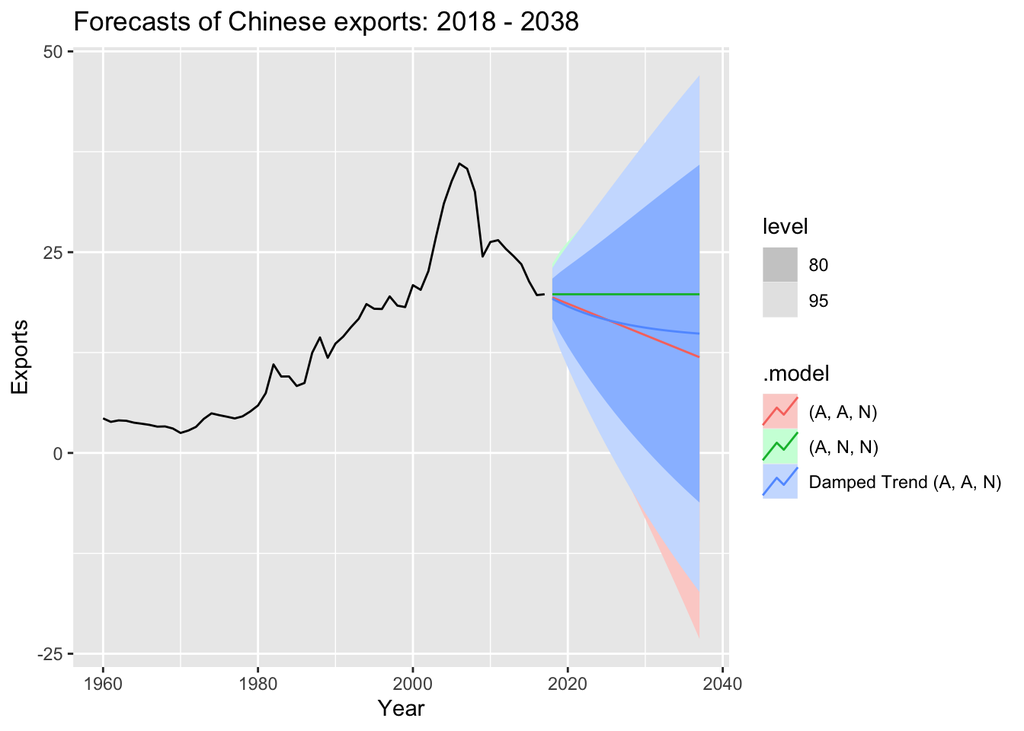

```r
china <- global_economy %>% filter(Country == "China")

china_fit <- china %>% model(
  `(A, A, N)` = ETS(Exports ~ error("A") + trend("A") + season("N")),
  `(A, N, N)` = ETS(Exports ~ error("A") + trend("N") + season("N")),
   `Damped Trend (A, A, N)` = ETS(Exports ~ error("A") +
                                trend("Ad", phi = 0.9) + season("N"))
  )
china_fc<- china_fit %>%
  forecast(h = 20)

china_fc %>% autoplot(china) + labs(y="Exports", title="Forecasts of Chinese exports: 2018 - 2038")
```

Looking at this forecast of 20 years out, we see that the damped method (blue) tends to have a less “extreme” impact than the forecast with a trend. This helps to account for reversals in the trend that the naive additive method (with a trend term) does not always account for.

## Exercise 8.7

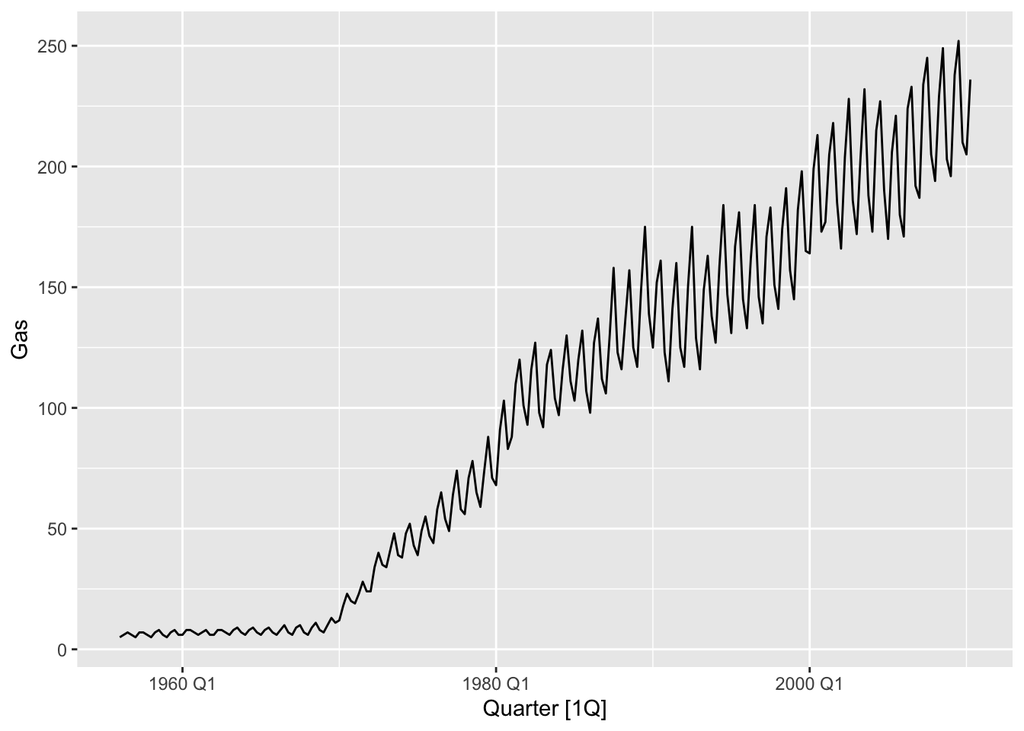

```r
aus_gas <- aus_production %>% select(Gas)
aus_gas %>% autoplot(Gas)
```

In this case, a multiplicative model would be best since the variance of our seasonality changes with time.

```r
gas_fit <- aus_gas %>%
    model(ETS(Gas ~ error("A") + trend("A") + season("M")))


gas_fc <- gas_fit %>% forecast(h=4)
```

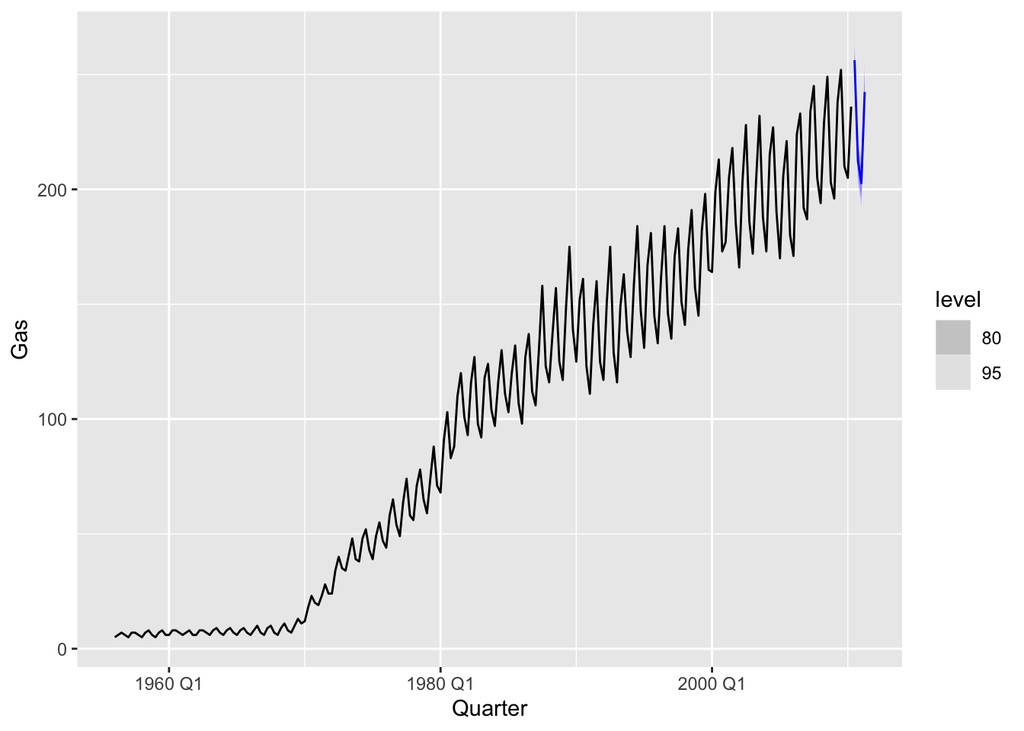

```r
# Plot gas forecast
gas_fc %>% autoplot(aus_gas)
```

```r
china_aug <- china_fit %>% augment()
var(china_aug$.resid)
```

```
## [1] 3.589456
```